# Assignment 3

Author

Erin Yu

## Text Mining

### Load data

```r
library(tidyverse)
library(tidytext)



url <- "https://raw.githubusercontent.com/USCbiostats/data-science-data/master/03_pubmed/pubmed.csv"
pubmed_data <- read_csv(url)
```

### Tokenize Data

```r
tokenized_data <- pubmed_data %>%
  unnest_tokens(token, abstract)
```

### Count Tokens without removing Stop Words

```r
token_count <- tokenized_data %>%
  count(token, sort = TRUE)


print(head(token_count, 10))
```

```
# A tibble: 10 × 2
   token     n
   <chr> <int>
 1 the   28126
 2 of    24760
 3 and   19993
 4 in    14653
 5 to    10920
 6 a      8245
 7 with   8038
 8 covid  7275
 9 19     7080
10 is     5649
```

The most common tokens without removing stop words were “the,” “of,” “and,” “in,” “to,” “a,” “with,” “covid,” “19,” and “is.” These were not very interesting words, and were mostly prepositions.

### Count tokens without stop words

```r
token_count_no_stopwords <- tokenized_data %>%
  anti_join(stop_words, by = c("token" = "word")) %>%
  count(token, sort = TRUE)


print(head(token_count_no_stopwords, 10))
```

```
# A tibble: 10 × 2
   token            n
   <chr>        <int>
 1 covid         7275
 2 19            7080
 3 patients      4674
 4 cancer        3999
 5 prostate      3832
 6 disease       2574
 7 pre           2165
 8 eclampsia     2005
 9 preeclampsia  1863
10 treatment     1841
```

After removing stop words, the 5 most common tokens were “covid,” “19,” “patient,” “cancer,” “prostate.” These changed after removing stop words, because these were all words that are not filler words.

### 5 most common tokens for each search term

```r
top_tokens_by_term <- tokenized_data %>%
  anti_join(stop_words, by = c("token" = "word")) %>%
  group_by(term) %>%
  count(token, sort = TRUE) %>%
  slice_max(n, n = 5) %>%
  ungroup()


print(top_tokens_by_term)
```

```
# A tibble: 25 × 3
   term            token        n
   <chr>           <chr>    <int>
 1 covid           covid     7275
 2 covid           19        7035
 3 covid           patients  2293
 4 covid           disease    943
 5 covid           pandemic   800
 6 cystic fibrosis fibrosis   867
 7 cystic fibrosis cystic     862
 8 cystic fibrosis cf         625
 9 cystic fibrosis patients   586
10 cystic fibrosis disease    400
# ℹ 15 more rows
```

For each search term, the 5 most common tokens were retrieved. For example, for the search term “prostate cancer,” the most common tokens were “cancer,” “prostate,” “patients,” “treatment,” and “disease”. For the search term preeclampsia, the most common tokens were “pre,” “eclampsia,” “preeclampsia,” “women,” and “pregnancy”.

### Tokenize data into bigrams

```r
bigrams <- pubmed_data %>%
  unnest_tokens(bigram, abstract, token = "ngrams", n = 2)
```

### Count bigram frequencies

```r
bigram_counts <- bigrams %>%
  count(bigram, sort = TRUE)
```

### Select top 10 most common bigrams

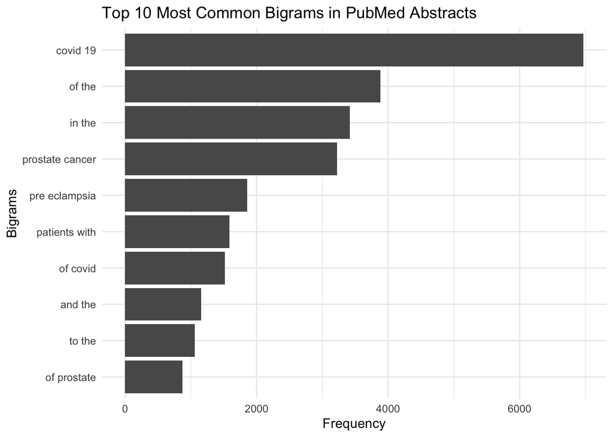

```r
top_10_bigrams <- bigram_counts %>%
  slice_max(n, n = 10)

top_10_bigrams %>%
  ggplot(aes(x = reorder(bigram, n), y = n)) +
  geom_bar(stat = "identity") +
  coord_flip() +
  labs(title = "Top 10 Most Common Bigrams in PubMed Abstracts",
       x = "Bigrams",
       y = "Frequency") +
  theme_minimal()
```

The top 10 most common bigrams are shown here, with “covid 19” being the most common at 7000, “of the” at around 3900, “in the” at around 3500, and “of prostate” being at the bottom near 800.

### Calculate token frequency and inverse document frequency

```r
term_frequency <- tokenized_data %>%
  count(term, token, sort = TRUE)

tf_idf <- term_frequency %>%
  bind_tf_idf(token, term, n) %>%
  arrange(desc(tf_idf))
```

### Find 5 tokens with the highest TF-IDF for each search term

```r
top_tokens_by_tf_idf <- tf_idf %>%
  group_by(term) %>%
  slice_max(tf_idf, n = 5) %>%
  ungroup()


print(top_tokens_by_tf_idf)
```

```
# A tibble: 25 × 6
   term            token           n      tf   idf  tf_idf
   <chr>           <chr>       <int>   <dbl> <dbl>   <dbl>
 1 covid           covid        7275 0.0371  1.61  0.0597
 2 covid           pandemic      800 0.00408 1.61  0.00657
 3 covid           coronavirus   647 0.00330 1.61  0.00531
 4 covid           sars          372 0.00190 1.61  0.00305
 5 covid           cov           334 0.00170 1.61  0.00274
 6 cystic fibrosis cf            625 0.0127  0.916 0.0117
 7 cystic fibrosis fibrosis      867 0.0176  0.511 0.00901
 8 cystic fibrosis cystic        862 0.0175  0.511 0.00896
 9 cystic fibrosis cftr           86 0.00175 1.61  0.00282
10 cystic fibrosis sweat          83 0.00169 1.61  0.00272
# ℹ 15 more rows
```

## Sentiment Analysis

### Perform Sentiment analysis using NRC Lexcion

```r
library(textdata)

nrc <- get_sentiments("nrc")

url <- "https://raw.githubusercontent.com/USCbiostats/data-science-data/master/03_pubmed/pubmed.csv"
pubmed_data <- read_csv(url) %>%
  rename(search_term = term)
tokenized_data <- pubmed_data %>%
  unnest_tokens(word, abstract) %>%  # Tokenizing abstracts
  anti_join(stop_words, by = "word") %>% # Remove stopwords
  distinct(search_term, word) # Keep only unique words per search term


sentiment_data <- tokenized_data %>%
  inner_join(nrc, by = "word") %>%
  count(search_term, sentiment, sort = TRUE)
```

### Most common sentiment for each term

```r
most_common_sentiment <- sentiment_data %>%
  group_by(search_term) %>%
  slice_max(n, n = 1) %>%
  ungroup()

print(most_common_sentiment)
```

```
# A tibble: 5 × 3
  search_term     sentiment     n
  <chr>           <chr>     <int>
1 covid           positive    623
2 cystic fibrosis positive    392
3 meningitis      positive    296
4 preeclampsia    positive    466
5 prostate cancer positive    513
```

The most common sentiment for each term was “positive,” for the terms covid, cystic fibrosis, meningitis, preeclampsia, and prostate cancer.

### Remove “positive” and “negative” and recalculate most common sentiments

```r
sentiment_data_no_pos_neg <- sentiment_data %>%
  filter(!sentiment %in% c("positive", "negative"))

most_common_sentiment_no_pos_neg <- sentiment_data_no_pos_neg %>%
  group_by(search_term) %>%
  slice_max(n, n = 1) %>%
  ungroup()


print(most_common_sentiment_no_pos_neg)
```

```
# A tibble: 5 × 3
  search_term     sentiment     n
  <chr>           <chr>     <int>
1 covid           trust       352
2 cystic fibrosis trust       211
3 meningitis      fear        161
4 preeclampsia    trust       255
5 prostate cancer trust       281
```

After removing “positive” and “negative,” the most common sentiments were “trust” and “fear”.

### Sentiment analysis using AFINN lexicon

```r
afinn <- get_sentiments("afinn")


url <- "https://raw.githubusercontent.com/USCbiostats/data-science-data/master/03_pubmed/pubmed.csv"
pubmed_data <- read_csv(url) %>%
  mutate(abstract_id = row_number())
tokenized_data <- pubmed_data %>%
  unnest_tokens(word, abstract) %>%
  anti_join(stop_words, by = "word") %>%
  select(abstract_id, term, word)
```

### Average positivity per abstract

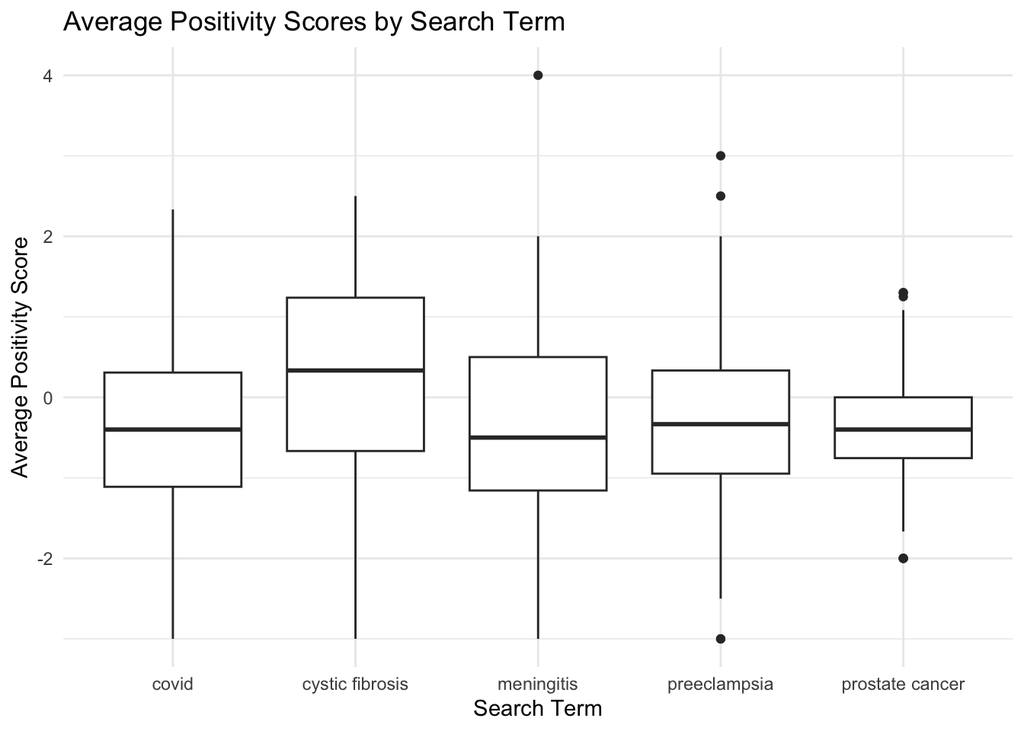

```r
abstract_sentiment <- tokenized_data %>%
  inner_join(afinn, by = "word") %>%
  group_by(abstract_id, term) %>%
  summarize(avg_positivity = mean(value, na.rm = TRUE)) %>%
  ungroup()
abstract_sentiment %>%
  ggplot(aes(x = term, y = avg_positivity)) +
  geom_boxplot() +
  labs(title = "Average Positivity Scores by Search Term",
       x = "Search Term",
       y = "Average Positivity Score") +
  theme_minimal()
```

The average positivity score for covid, meningitis, preeclampsia, and prostate cancer were all negative values. However, cystic fibrosis was the only term that seemed to have a an average score that was around +0.4, making it different than the others.